# Effect of Bike Hiring Characteristics on Trip Duration

## by Eunice Oduwole

## Investigation Overview

In this investigation, I wanted to look at the characteristics of bike hiring that could be used to predict trip duration. The main focus was on the day of the week, user type (subscriber or customer i.e casual user) and hours of the day.

## Dataset Overview

The consist of trip duration and attributes of about 192082 entries. The attribute included four feature, with other attribute such as bike_share_for_all_trip, start_station_name, start station id. Two more features were added such that we have entries for time in term of day and time (extracted from the start time column).

## Distribution of trip durations

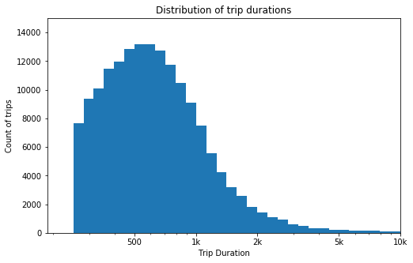

```python
log_binsize = 0.05
bins_log = 10 ** np.arange(2.4, np.log10(tripdata_copy.duration_sec.max()) + log_binsize, log_binsize)

plt.figure(figsize=[8, 5])
plt.hist(data = tripdata_copy, x = 'duration_sec', bins = bins_log)
plt.title('Distribution of trip durations')
plt.xlabel('Trip Duration')
plt.ylabel('Count of trips')
plt.xscale('log')
plt.xticks([500, 1e3, 2e3, 5e3, 1e4], [500, '1k', '2k', '5k', '10k'])
plt.axis([0, 10000, 0, 15000])
plt.show()
```

## Distribution of hours of the day

The distribution of the hour of day is roughly bimodal, with the first peak roughly between 8:00 and 10:00. There is a sharp drop in the trip frequency after, this could probably be because people are now settled for the day's activities such as office work, school etc. Again the trip start increase at about 14:00 and reaches it's second peak about 16:00 and gradually decreases. Again, this could be attributed to fact that people are closed for the day and take this bike trip to there various destinations.

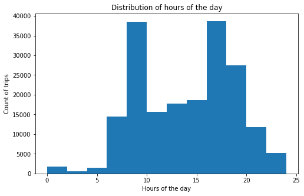

```python
bins = np.arange(0, tripdata_copy.hours_of_the_day.max()+2, 2)
plt.figure(figsize=[8, 5])
plt.hist(data = tripdata_copy, x = 'hours_of_the_day', bins = bins);
plt.title('Distribution of hours of the day')
plt.xlabel('Hours of the day')
plt.ylabel('Count of trips')
plt.show()
```

## Distribution of trips for days of the week

This chart reveals that more trips were taken during the working days (Monday - Friday). With Thursday having a higher trip count.

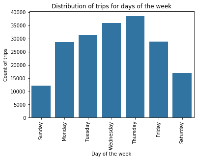

```python
default_color = sb.color_palette()[0]
sb.countplot(data = tripdata_copy, x = 'day_of_the_week', color = default_color);
plt.title('Distribution of trips for days of the week')
plt.xlabel('Day of the week')
plt.ylabel('Count of trips')
plt.xticks(rotation = 90);
```

## Count of trips for users

The chart reveals that subscribers take more trips than the causal uers (customer).

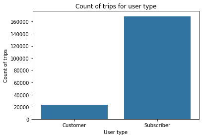

```python
default_color = sb.color_palette()[0];
sb.countplot(data = tripdata_copy, x = 'user_type', color = default_color);
plt.title('Count of trips for user type');
plt.xlabel('User type');
plt.ylabel('Count of trips');
```

## User type versus Trip duration

Plotting user type against the trip duartion, it is quite interesying to see that casual users(cutomer) took a longer trip duration than the subsriber who had higher trip count from the previous chart. We can probably say casual user mostly took the trip when they have to go a longer distance to go, while subcribers take the bike trip on a dialy basis.

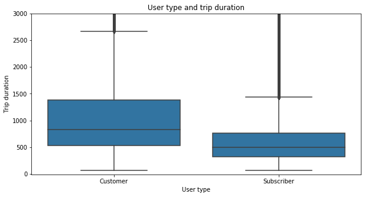

```python
plt.figure(figsize = [10, 5])
base_color = sb.color_palette()[0]
sb.boxplot(data = tripdata_copy, x = 'user_type', y = 'duration_sec', color = base_color)
plt.ylim([-10, 3000])
plt.title('User type and trip duration')
plt.xlabel('User type')
plt.ylabel('Trip duration')
plt.show()
```

## Trip Duration versus day of the week

This plot reveal that the longer trips occurs on Sundays and Saturdays. Probably because it's a free day for most people.

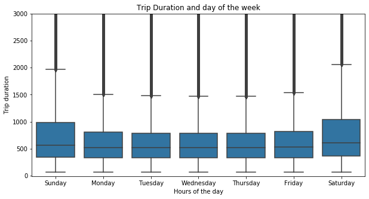

```python
plt.figure(figsize = [10, 5])
base_color = sb.color_palette()[0]
sb.boxplot(data = tripdata_copy, x = 'day_of_the_week', y = 'duration_sec', color = base_color)
plt.ylim([-10, 3000])
plt.title('Trip Duration and day of the week')
plt.xlabel('Hours of the day')
plt.ylabel('Trip duration')
plt.show()
```

## Trip duration and hour by days of the week

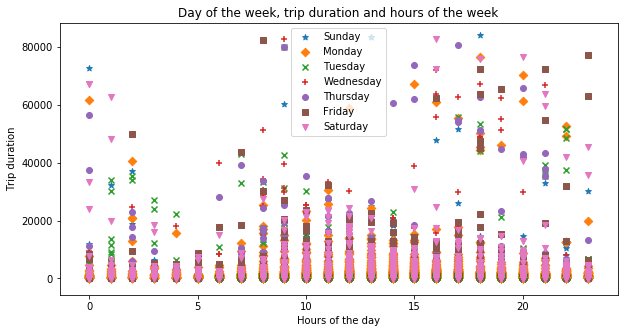

```python
plt.figure(figsize = [10, 5])
categoric_vars = [['Sunday', '*'],['Monday','D'],['Tuesday','x'],['Wednesday','+'],['Thursday', 'o'], ['Friday','s'], ['Saturday','v']]
for day,markers in categoric_vars:
    tripdata_day = tripdata_copy[tripdata_copy['day_of_the_week'] == day]
    plt.scatter((tripdata_day['hours_of_the_day']), tripdata_day['duration_sec'], marker = markers, alpha= 1)
plt.legend(['Sunday','Monday','Tuesday','Wednesday','Thursday', 'Friday', 'Saturday'])
plt.title('Day of the week, trip duration and hours of the week')
plt.xlabel('Hours of the day')
plt.ylabel('Trip duration')
plt.show()
```

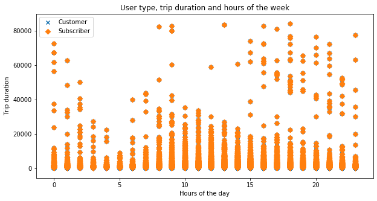

```python
plt.figure(figsize = [10, 5])
categoric_vars =  [['Customer', 'x'],['Subscriber', 'D']]
for user,markers in categoric_vars:
    tripdata_user = tripdata_copy[tripdata_copy['user_type'] == day]
    plt.scatter((tripdata_copy['hours_of_the_day']), tripdata_copy['duration_sec'], marker = markers, alpha= 1)

plt.legend(['Customer','Subscriber'])
plt.title('User type, trip duration and hours of the week')
plt.xlabel('Hours of the day')
plt.ylabel('Trip duration')
plt.show()
```

```python
!jupyter nbconvert slide_deck.ipynb --to slides --post serve --template output_toggle
```

[output not shown]